# Assignment 4: PERMANOVA

Luke Ghallahorne

2025-05-22

```r
library(vegan)
library(tidyverse)
library(GGally)
```

# Introduction.

Fish community composition is one of many factors that could be affected by changes in seagrass abundance, as seagrass beds provide habitat for many marine animals. In Chesapeake Bay, seagrass beds have been diminishing over past decades due to lower water clarity and higher temperatures. Sobocinski et al. (2013) used historical and present fish capture data to assess the impact of dwindling seagrass habitat on fish community composition. In particular, I will use these data to answer the question: **Do present day fish populations differ from historical ones in the Chesapeake Bay?**

# Methods.

## Loading Data.

First, I load the data and examine the structure of the dataframe. I save the response variables as a matrix, as needed for the permutation function.

```r
#Data Loading
fish <- read.csv("Data/fish_assignment.csv", stringsAsFactors = TRUE)
# head(fish)
# str(fish)

Y <- as.matrix(fish[,3:9])
```

The response variables in the dataset are counts of fish species: atlantic silverside, bay anchovy, ducky pipefish, mummichog, northern pipefish, silver perch, and spot.

## Normality.

I then test for normality of response variables and correlation between them using a pairs plot matrix with all seven fish counts, colored by present or historical data set.

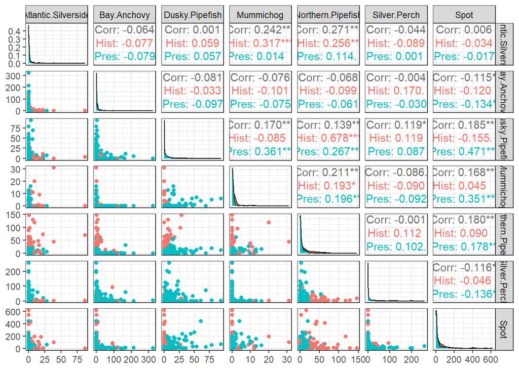

```r
# Normality
p1 <- ggpairs(fish[,c(3:9)], aes(color = fish$Data.Set))+
  theme_bw()
p1
```

## Dispersion: Dissimilarity Measures.

Next, I creat dissimilarity matrices with different measurements to assess dispersion between the variables.

### Euclidean.

I start with Euclidean distances.

```r
# Euclidean
# 1) Create dissimilarity matrix
fish.dis <- vegdist(Y, method = "euclidean")

fish.set <- fish$Data.Set
fish.mod1 <- betadisper(fish.dis, fish.set)
anova(fish.mod1)
```

```
## Analysis of Variance Table
##
## Response: Distances
##            Df  Sum Sq Mean Sq F value    Pr(>F)
## Groups      1   62615   62615  12.082 0.0005672 ***
## Residuals 384 1990012    5182
## ---
## Signif. codes:  0 '***' 0.001 '**' 0.01 '*' 0.05 '.' 0.1 ' ' 1
```

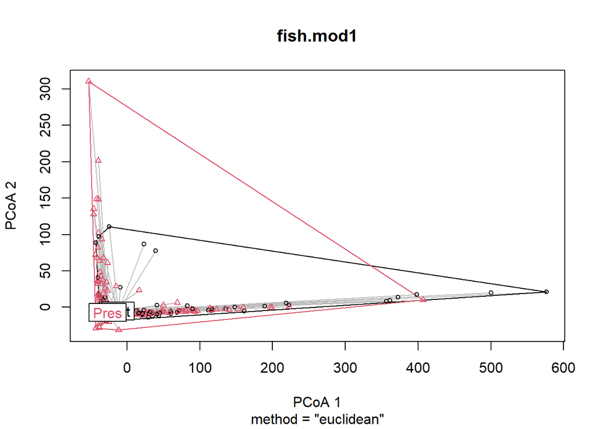

```r
plot(fish.mod1)
```

When measured with Euclidean distances, mean distances to the median of each group (historic and present) were significantly different from each other ($F$<sub>1,384</sub> = 12.1, p < 0.001). The plot of dissimilarity measures shows that the data are quite skewed towards zeros. Euclidean measurements are likely not the best distance measures for these data.

### Standardized Euclidean.

I next examine the standardized Euclidean distances.

```r
# Standardized Euclidean
Ys <- scale(Y)
fish.dis2 <- vegdist(Ys, method = "euclidean")
fish.set <- fish$Data.Set
fish.mod2 <- betadisper(fish.dis2, fish.set)
anova(fish.mod2)
```

```
## Analysis of Variance Table
##
## Response: Distances
##            Df  Sum Sq Mean Sq F value   Pr(>F)
## Groups      1   33.07  33.070  8.5083 0.003743 **
## Residuals 384 1492.50   3.887
## ---
## Signif. codes:  0 '***' 0.001 '**' 0.01 '*' 0.05 '.' 0.1 ' ' 1
```

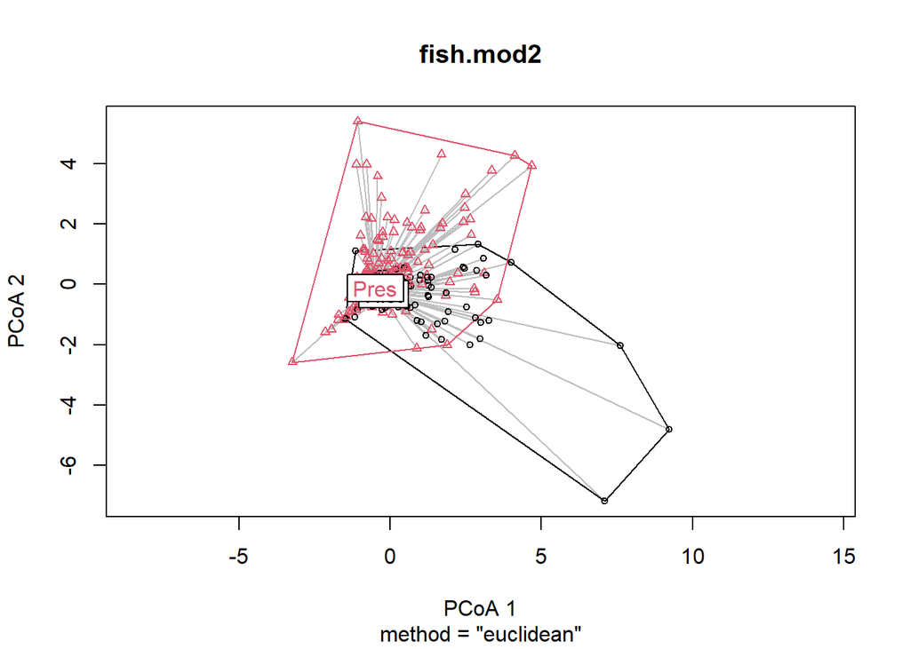

```r
plot(fish.mod2)
```

Standardizing prior to measuring Euclidean distance resulted in a significant difference between mean distance to the median for historic vs present data sets ($F$<sub>1,384</sub> = 8.5, p = 0.0037). The distances are more evenly spread, as seen in the plot of principle coordinate axes 1 and 2, but there is still some wide spread, particularly in the historic data.

### Bray-Curtis.

I finally check the distance measures using Bray-Curtis measurements, which are typically appropriate for count data with many zeros.

```r
# Bray-Curtis
fish.dis3 <- vegdist(Y, method = "bray")

fish.set <- fish$Data.Set
fish.mod3 <- betadisper(fish.dis3, fish.set)
anova(fish.mod3)
```

```
## Analysis of Variance Table
##
## Response: Distances
##            Df Sum Sq   Mean Sq F value Pr(>F)
## Groups      1 0.0020 0.0020153  0.1431 0.7055
## Residuals 384 5.4095 0.0140871
```

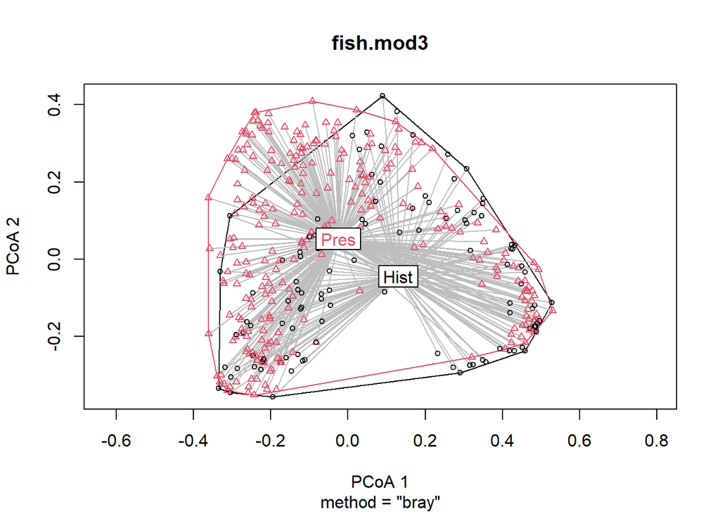

```r
plot(fish.mod3)
```

Bray-Curtis distance measures show no significant difference in mean distance to the median ($F$<sub>1,384</sub> = 0.14, p = 0.71). The PCoA plot shows that the measures are much more evenly spread with Bray-Curtis.

Since these data are count data with many zeros, the Bray-Curtis distance measures better represent the dissimilarity between points and I will continue with the analysis using that distance matrix.

## PERMANOVA.

To perform the PERMANOVA, I first set the seed for replicability, then perform a permutation analysis of variance between historic and present pulls with $Y \sim Data.set$ as my model.

```r
set.seed(42)
ado1 <- adonis2 (Y ~ fish$Data.Set, method = "bray")
ado1
```

```
## Permutation test for adonis under reduced model
## Permutation: free
## Number of permutations: 999
##
## adonis2(formula = Y ~ fish$Data.Set, method = "bray")
##           Df SumOfSqs      R2      F Pr(>F)
## Model      1    4.311 0.03443 13.691  0.001 ***
## Residual 384  120.918 0.96557
## Total    385  125.230 1.00000
## ---
## Signif. codes:  0 '***' 0.001 '**' 0.01 '*' 0.05 '.' 0.1 ' ' 1
```

The model shows that fish community composition in Chesapeake Bay is significantly different between historical and present day pulls (pseudo-$F$<sub>(1,384)</sub> = 13.7, p < 0.001). However, time of data collection only accounted for 3.4% of the variation in community compositions ($R^2$ = 0.034).

A density plot of the permutations calculated by the PERMANOVA visualize the rarity of getting our result based on 999 permutations of the data.

```r
fish.perms <- permustats(ado1)
summary(fish.perms)
```

```
##
##       statistic     SES    mean lower  median   upper Pr(perm)
## Model   13.6915 25.4213  1.0043        0.8905  2.0234    0.001 ***
## ---
## Signif. codes:  0 '***' 0.001 '**' 0.01 '*' 0.05 '.' 0.1 ' ' 1
##
## (Interval (Upper - Lower) = 0.95)
```

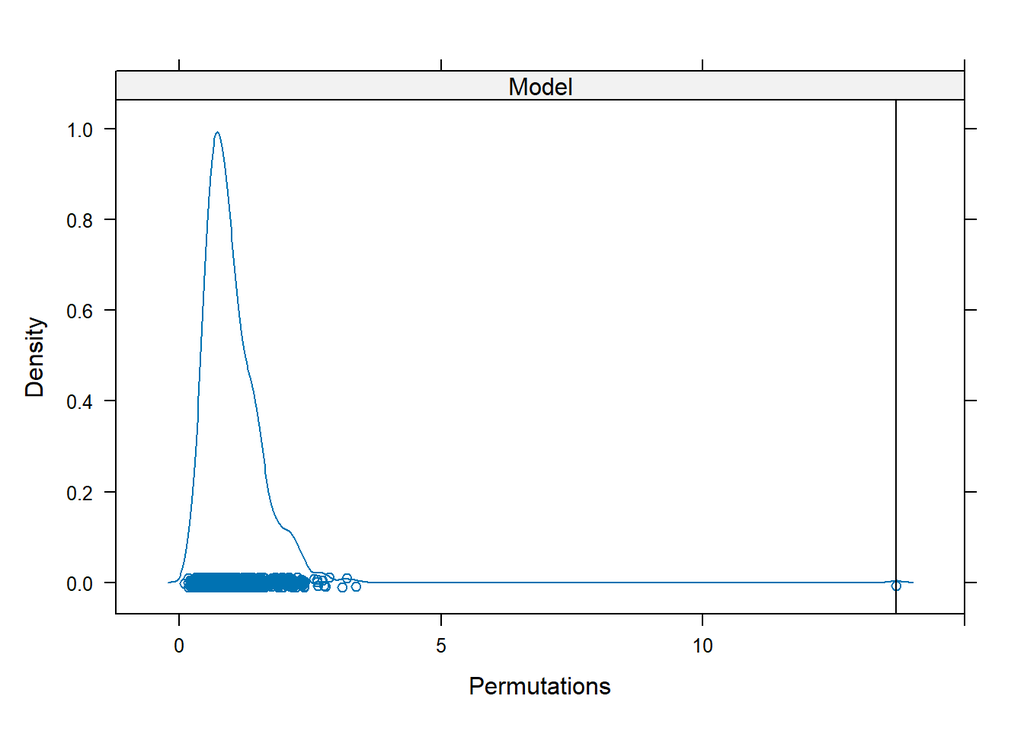

```r
  # statistic is observed statistic
  # SES is standardized effect size of that statistic based on the mean and sd of permutation under null
  # mean are means of permutations by column
  # median medians of permutations
  # upper is upper bound for 95% CI

densityplot(fish.perms)
```

# Results.

```r
# Creating a vector of means for each fish species by historic or present dataset.
fish.means <- aggregate(fish[,-c(1:2)], FUN = mean,
                        by = list(fish$Data.Set))

# Tidying the data into long format.
means.long <- fish.means |>
  gather(key = "Species", value = "Mean", 2:8,
         factor_key = TRUE)
#means.long

colnames(means.long) <- c("Dataset", "Species", "Mean")
```

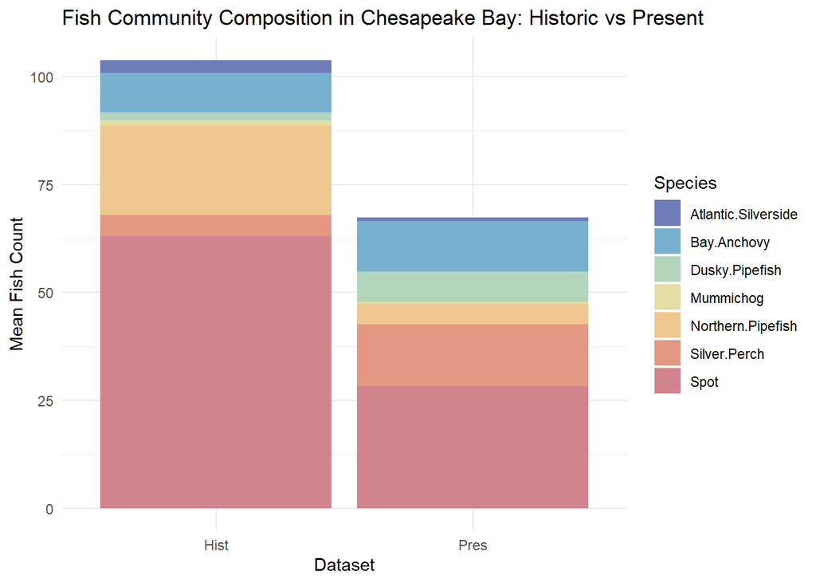

```r
# Setting up color palette.
pal1 <- PNWColors::pnw_palette("Sailboat", 7, type = "continuous")

# Stacked bar plot to visualize differences in composition
fp <- means.long |>
  ggplot(aes(x = Dataset, y = Mean, fill = Species)) +
  geom_bar(stat = "identity") +
  theme_minimal() +
  scale_fill_manual(values = pal1) +
  ggtitle("Fish Community Composition in Chesapeake Bay: Historic vs Present") +
  ylab("Mean Fish Count")
fp
```

# Conclusion.

Fish community composition in Chesapeake Bay is significantly different in the present compared to historic levels (pseudo-$F$<sub>(1,384)</sub> = 13.7, p < 0.001).

However, there are very likely other factors contributing to this difference, as time only accounted for 3.4% of the variation between groups ($R^2$ = 0.034).

This isn’t terribly surprising, as the data are a subset of a much larger dataframe that includes many other variables that might explain more variation.

# Reflection.

Running the PERMANOVA and interpreting the results felt fairly straightforward for this assignment. Going through Euclidean, standardized Euclidean, and Bray-Curtis measurements sequentially really helped show how different measures give different representations of the data.

My apologies for not getting the draft version in this week. It has been a tough one inside and outside of school.